# quiz6.16

```python
import numpy as np
import pandas as pd
import statsmodels.formula.api as smf
import matplotlib.pyplot as plt
%matplotlib inline
```

#### C1

Use the data in WAGE1 for this exercise.

- (i) Estimate the equation $$ wage=\beta_0+\beta_1 educ+\beta_2 exper+\beta_3 tenure+u. $$ Save the residuals and plot a histogram.
- (ii) Repeat part (i), but with log(wage) as the dependent variable.
- (iii) Would you say that Assumption MLR.6 is closer to being satisfied for the level-level model or the log-level model?

```python
data=pd.read_table('data_text/wage1.txt',sep='\s+',na_values='.')
data.columns
```

```
Index(['wage', 'educ', 'exper', 'tenure', 'nonwhite', 'female', 'married',
       'numdep', 'smsa', 'northcen', 'south', 'west', 'construc', 'ndurman',
       'trcommpu', 'trade', 'services', 'profserv', 'profocc', 'clerocc',
       'servocc', 'lwage', 'expersq', 'tenursq'],
      dtype='object')
```

(i) Estimate the equation $$ wage=\beta_0+\beta_1 educ+\beta_2 exper+\beta_3 tenure+u. $$ Save the residuals and plot a histogram.

```
Intercept   -2.872735
educ         0.598965
exper        0.022340
tenure       0.169269
dtype: float64
n=526.0,r2=0.3064
```

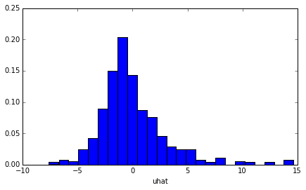

```python
res=smf.ols(formula='wage~educ+exper+tenure',data=data).fit()
print(res.params)
print('n={0},r2={1:.4f}'.format(res.nobs,res.rsquared))
resid=res.resid
plt.figure(figsize=(7,4))
plt.hist(resid,bins=25,weights=np.zeros_like(resid) + 1./resid.size)
plt.xlabel('uhat')
```

(ii) Repeat part (i), but with log(wage) as the dependent variable.

- 怎么加一条正态分布曲线

```
Intercept    0.284359
educ         0.092029
exper        0.004121
tenure       0.022067
dtype: float64
n=526.0,r2=0.3160
```

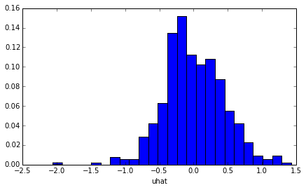

```python
res=smf.ols(formula='lwage~educ+exper+tenure',data=data).fit()
print(res.params)
print('n={0},r2={1:.4f}'.format(res.nobs,res.rsquared))
resid=res.resid
plt.figure(figsize=(7,4))
plt.hist(resid,bins=25,weights=np.zeros_like(resid) + 1./resid.size)
plt.xlabel('uhat')
```

(iii) Would you say that Assumption MLR.6 is closer to being satisfied for the level-level model or the log-level model?

the log-lebel model

#### C2

Use the data in GPA2 for this exercise.

- (i) Using all 4,137 observations, estimate the equation $$ colgpa=\beta_0+\beta_1 hsperc+\beta_2 sat+u $$ and report the results in standard form.
- (ii) Reestimate the equation in part (i), using the first 2,070 observations.
- (iii) Find the ratio of the standard errors on hsperc from parts (i) and (ii). Compare this with the result from (5.10) $$ se(\hat{\beta}_j)\approx c_j/\sqrt{n}. $$

```python
data=pd.read_table('data_text/gpa2.txt',sep='\s+',na_values='.')
data.columns
```

```
Index(['sat', 'tothrs', 'colgpa', 'athlete', 'verbmath', 'hsize', 'hsrank',
       'hsperc', 'female', 'white', 'black', 'hsizesq'],
      dtype='object')
```

```python
res=smf.ols(formula='colgpa~hsperc+sat',data=data).fit()
print(res.params)
print('n={0},r2={1:.4f}'.format(res.nobs,res.rsquared))
a=res.HC1_se[1]
```

```
Intercept    1.391757
hsperc      -0.013519
sat          0.001476
dtype: float64
n=4137.0,r2=0.2734
```

```python
data1=data[:2070]
res=smf.ols(formula='colgpa~hsperc+sat',data=data1).fit()
print(res.params)
print('n={0},r2={1:.4f}'.format(res.nobs,res.rsquared))
b=res.HC1_se[1]
```

```
Intercept    1.436017
hsperc      -0.012749
sat          0.001468
dtype: float64
n=2070.0,r2=0.2827
```

```python
print(a,b)
print(b/a)
print(np.sqrt(4137/2070))
```

```
0.000554405870597 0.0007063083067
1.27399139179
1.4137010733
```

#### C3

In equation (4.42) of Chapter 4, $$ bwght=\beta_0+\beta_1 cigs+\beta_2 parity+\beta_3 faminc+\beta_4 motheduc+\beta_5 fatheduc+u, $$ using the data set BWGHT, compute the LM statistic for testing whether motheduc and fatheduc are jointly significant. In obtaining the residuals for the restricted model, be sure that the restricted model is estimated using only those observations for which all variables in the unrestricted model are available (see Example 4.9).

```python
data=pd.read_table('data_text/bwght.txt',sep='\s+',na_values='.')
data.columns
```

```
Index(['faminc', 'cigtax', 'cigprice', 'bwght', 'fatheduc', 'motheduc',
       'parity', 'male', 'white', 'cigs', 'lbwght', 'bwghtlbs', 'packs',
       'lfaminc'],
      dtype='object')
```

```python
data=data[data.motheduc.notnull()][data.fatheduc.notnull()]
res=smf.ols(formula='bwght~cigs+parity+faminc',data=data).fit()
print(res.params)
print('n={0},r2={1:.4f}'.format(res.nobs,res.rsquared))
```

```
Intercept    115.469925
cigs          -0.597852
parity         1.832274
faminc         0.067062
dtype: float64
n=1191.0,r2=0.0364
```

```python
data['uhat']=res.resid
res1=smf.ols(formula='uhat~cigs+parity+faminc+motheduc+fatheduc',data=data).fit()
print(res1.params)
print('n={0},r2={1:.4f}'.format(res1.nobs,res1.rsquared))
lm=res1.nobs*res1.rsquared
print('LM:',lm)
```

```
Intercept   -0.945597
cigs         0.001916
parity      -0.044671
faminc      -0.011020
motheduc    -0.370450
fatheduc     0.472394
dtype: float64
n=1191.0,r2=0.0024
LM: 2.88210058436
```

```python
res1.compare_lm_test(res)
```

```
(2.882100584363124, 0.23667904594296879, 2.0)
```

```python
res=smf.ols(formula='bwght~cigs+parity+faminc',data=data).fit()
res1=smf.ols(formula='bwght~cigs+parity+faminc+motheduc+fatheduc',data=data).fit()
res1.compare_lm_test(res)
```

```
(2.882100584363124, 0.23667904594296879, 2.0)
```

#### C4

Several statistics are commonly used to detect nonnormality in underlying population distributions. Here we will study one that measures the amount of skewness in a distribution. Recall that any normally distributed random variable is symmetric about its mean; therefore, if we standardize a symmetrically distributed random variable, say $z=(y-\mu_y)/\sigma_y$, where $\mu_y=E(y)$ and $\sigma_y=sd(y)$, then z has mean zero, variance one, and $E(z^3)=0$. Given a sample of data $\{y_i: i=1,...,n\}$, we can standardize $y_i$ in the sample by using $z_i=(y_i-\hat{\mu}_y)/\hat{\sigma}_y$, where $\hat{\mu}_y$ is the sample mean and $\hat{\sigma}_y$ is the sample standard deviation. (We ignore the fact that these are estimates based on the sample.) A sample statistic that measures skewness is $n^{-1}\sum_{i=1}^n z_i^3$, or where n is replaced with (n-1) as a degrees-of-freedom adjustment. If y has a normal distribution in the population, the skewness measure in the sample for the standardized values should not differ significantly from zero.

- (i) First use the data set 401KSUBS, keeping only observations with fsize=1. Find the skewness measure for inc. Do the same for log(inc). Which variable has more skewness and therefore seems less likely to be normally distributed?
- (ii) Next use BWGHT2. Find the skewness measures for bwght and log(bwght). What do you conclude?
- (iii) Evaluate the following statement: “The logarithmic transformation always makes a positive variable look more normally distributed.”
- (iv) If we are interested in the normality assumption in the context of regression, should we be evaluating the unconditional distributions of y and log(y)? Explain.

```python
data=pd.read_table('data_text/401ksubs.txt',sep='\s+',na_values='.')
data=data[data.fsize == 1]
data.columns
```

```
Index(['e401k', 'inc', 'marr', 'male', 'age', 'fsize', 'nettfa', 'p401k',
       'pira', 'incsq', 'agesq'],
      dtype='object')
```

```python
data['binc']=(data.inc-data.inc.mean())/data.inc.std()
data['linc']=np.log(data.inc)
data['blinc']=(data.linc-data.linc.mean())/data.linc.std()
```

```python
print(sum(data.binc**3)/len(data))
print(sum(data.blinc**3)/len(data))
```

```
1.86225870102
0.360603067624
```

```python
data=pd.read_table('data_text/BWGH2.txt',sep='\s+',na_values='.')
data.columns
```

```
Index(['mage', 'meduc', 'monpre', 'npvis', 'fage', 'feduc', 'bwght', 'omaps',
       'fmaps', 'cigs', 'drink', 'lbw', 'vlbw', 'male', 'mwhte', 'mblck',
       'moth', 'fwhte', 'fblck', 'foth', 'lbwght', 'magesq', 'npvissq'],
      dtype='object')
```

```python
data['bbwght']=(data.bwght-data.bwght.mean())/data.bwght.std()
data['lbwght']=np.log(data.bwght)
data['blbwght']=(data.lbwght-data.lbwght.mean())/data.lbwght.std()
print(sum(data.bbwght**3)/len(data))
print(sum(data.blbwght**3)/len(data))
```

```
-0.600156294627
-2.94861624981
```

#### C5

Consider the analysis in Computer Exercise C11 in Chapter 4 using the data in HTV, where educ is the dependent variable in a regression.

- (i) How many different values are taken on by educ in the sample? Does educ have a continuous distribution?
- (ii) Plot a histogram of educ with a normal distribution overlay. Does the distribution of educ appear anything close to normal?
- (iii) Which of the CLM assumptions seems clearly violated in the model $$educ=\beta_0+\beta_1 motheduc+\beta_2 fatheduc+\beta_3 abil+\beta_4 abil^2+u? $$ How does this violation change the statistical inference procedures carried out in Computer Exercise C11 in Chapter 4?

```python
data=pd.read_table('data_text/htv.txt',sep='\s+',na_values='.')
data.columns
```

```
Index(['wage', 'abil', 'educ', 'ne', 'nc', 'west', 'south', 'exper',
       'motheduc', 'fatheduc', 'brkhme14', 'sibs', 'urban', 'ne18', 'nc18',
       'south18', 'west18', 'urban18', 'tuit17', 'tuit18', 'lwage', 'expersq',
       'ctuit'],
      dtype='object')
```

```python
set(data.educ)
```

```
{6, 7, 8, 9, 10, 11, 12, 13, 14, 15, 16, 17, 18, 19, 20}
```

```python
from scipy.stats import norm
```

```python
data.beduc=(data.educ-data.educ.mean())/data.educ.std()
```

- 怎么把直方图的纵轴显示频率而不是频数？没找到参数

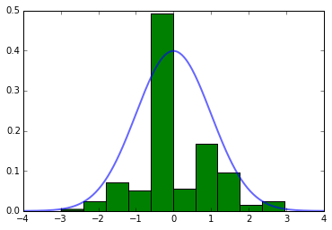

```python
fig, ax = plt.subplots()
x = np.linspace(-4, 4, 300)
y = norm.pdf(x, loc=0, scale=1)
ax.plot(x, y, linewidth=2, alpha=0.6)
ax.hist(data.beduc,weights=np.zeros_like(data.beduc) + 1./data.beduc.size)#后来尝试的一种方法
plt.show()
```

- CLM 6
- 不满足正态分布假设，不能做统计推断

```python
data.size
```

```
28290
```

#### C6

Use the data in ECONMATH to answer this question.

- (i) Logically, what are the smallest and largest values that can be taken on by the variable score? What are the smallest and largest values in the sample?
- (ii) Consider the linear model $$ score=\beta_0+\beta_1 colgpa+\beta_2 actmth+\beta_3 acteng+u. $$ Why cannot Assumption MLR.6 hold for the error term u? What consequences does this have for using the usual t statistic to test $H_0: \beta_3=0$?
- (iii) Estimate the model from part (ii) and obtain the t statistic and associated p-value for testing $H_0: \beta_3=0$. How would you defend your findings to someone who makes the following statement: “You cannot trust that p-value because clearly the error term in the equation cannot have a normal distribution.”

```python
data=pd.read_csv('data_text/econmath.csv',na_values='.')
data.columns
```

```
Index(['age', 'work', 'study', 'econhs', 'colgpa', 'hsgpa', 'acteng', 'actmth',
       'act', 'mathscr', 'male', 'calculus', 'attexc', 'attgood', 'fathcoll',
       'mothcoll', 'score'],
      dtype='object')
```

```python
print(data.score.max())
print(data.score.min())
```

```
98.44
19.53
```

```python
res=smf.ols(formula='score~colgpa+actmth+acteng',data=data).fit()
print(res.params)
print('n={0},r2={1:.4f}'.format(res.nobs,res.rsquared))
```

```
Intercept    16.174018
colgpa       12.366201
actmth        0.883352
acteng        0.051764
dtype: float64
n=814.0,r2=0.3972
```

[figure not shown]

```python
plt.hist(a,bins=100,weights=(np.zeros_like(a) + 1.)/len(a))
plt.show()
```

```python
res.t_test('acteng')
```

```
<class 'statsmodels.stats.contrast.ContrastResults'>
                             Test for Constraints
==============================================================================
                 coef    std err          t      P>|t|      [95.0% Conf. Int.]
------------------------------------------------------------------------------
c0             0.0518      0.111      0.466      0.641        -0.166     0.270
==============================================================================
```